# Eléments de statistique descriptive avec R

Mohamad Ghassany

30/03/2018

### Données utilisées

Une enquête a été réalisée sur 237 étudiants. Les données sont les suivantes:

- **Sex**: The sex of the student. (Factor with levels “Male” and “Female”.)
- **Wr.Hnd**: span (distance from tip of thumb to tip of little finger of spread hand) of writing hand, in centimetres.
- **NW.Hnd**: span of non-writing hand.
- **W.Hnd**: writing hand of student. (Factor, with levels “Left” and “Right”.)
- **Fold**: “Fold your arms! Which is on top” (Factor, with levels “R on L”, “L on R”, “Neither”.)
- **Pulse**: pulse rate of student (beats per minute).
- **Clap**: ‘Clap your hands! Which hand is on top?’ (Factor, with levels “Right”, “Left”, “Neither”.)
- **Exer**: how often the student exercises. (Factor, with levels “Freq” (frequently), “Some”, “None”.)
- **Smoke**: how much the student smokes. (Factor, levels “Heavy”, “Regul” (regularly), “Occas” (occasionally), “Never”.)
- **Height**: height of the student in centimetres.
- **M.I**: whether the student expressed height in imperial (feet/inches) or metric (centimetres/metres) units. (Factor, levels “Metric”, “Imperial”.)
- **Age**: age of the student in years.

### Définition du répertoire de travail

Vous avez la possibilité de définir un *Répertoire de travail* dans lequel vous allez stocker votre script R, vos données etc… Ceci est réalisé par la fonction `setwd("..Chemin/de/votre/repertoire")`. Cette fonction considère comme seul paramètre le chemin d’accès au répertoire que vous avez choisi. A tout moment, vous pouvez vérifier le répertoire de travail courant en executant l’instruction suivante:

```r
getwd()
```

**1**. Définisser votre répertoire de travail.

### Chargement des données

Il existe une multitude de fonctions qui permettent de charger un fichier de données. Télécharger le fichier de données en cliquant ici et enregistrer le dans votre répertoire. Ensuite utiliser la fonction `read.csv()` pour charger les données dans `R`. Cette fonction prend comme principaux paramètres d’entrée le fichier à charger `(file="data.txt")`, le séparateur de colonnes dans le fichier initial `(sep=)` et la présence (ou non) des noms de colonnes dans le fichier `(header=)`.

Ouvrez toujours le fichier de données dans un éditeur de texte pour connaitre le séparateur de colonnes et voir si les nom de colonnes sont présents.

**2.** Charger le fichier des données dans l’enquête dans un tableau nommé `data`. L’instruction de chargement du fichier est la suivante:

```r
donnees = read.csv("enquete.csv", header = T , sep=",")
```

Le fichier de données est chargé dans l’environnement `R` et est affecté à l’objet `donnees`. C’est cet objet, de type *dataframe* qui va faire l’objet de manipulations par la suite.

**3.** Afficher le nombre de d’observations (lignes) et le nombre de variables (colonnes).

**4.** Utiliser la fonction `head()` pour afficher les premières lignes (6 par défaut) de données chargées.

**5.** L’accès à une colonne d’un dataframe se fait par la notation `$`: `nom_du_dataframe$nom_variable`. Afficher les valeurs de la variable `Age` de vos données.

### Analyse descriptive univariée

**Indicateurs statistiques pour variables quantitatives**

**6.** Calculer et afficher la moyenne et l’écart-type d’age des élèves qui ont participé à l’enquête.

**7.** Appliquer la fonction `summary()` sur la variable `Age`. Qu’est ce que cette fonction calcule et affiche?

**Représentations graphiques pour variables quantitatives**

**8.** Tracer l’histogramme de la variable `Age`. Ecrire un titre correspondante à votre figure, modifier les noms des axes et les couleurs des bâtons.

**9.** Afficher une la boîte à moustache correspondante à la variable `Age`. Commenter ce qu’on observe sur cette figure.

**Indicateurs statistiques et représentations graphiques pour variables qualitatives**

**10.** Choisir une variable qualitative parmi les variables de cette enquête. Justifier votre choix. Calculer et afficher les effectifs et les fréquences de cette variable.

Pour voir les variables dans votre dataframe, vous pouvez utiliser la fonction `names()` pour afficher les noms des variables, ou `str()` (structure) pour voir toutes les colonnes, leur types, les quelques premières valeurs, etc.. Ou simplement dans Rstudio on peut voir la structure du dataframe dans la fenêtre “Environment”.

**11.** Afficher un diagramme circulaire (en utilisant la fonction `pie()`) pour la variable qualitative choisie.

### Analyse descriptive bivariée

C’est une partie que nous n’avons pas encore abordé en cours. Mais on va quand même faire une petite analyse sur R et définir les notions théoriques plus tard.

**Indicateurs pour le croisement de deux variables qualitatives**

Le tableau de contingence est un moyen particulier de représenter simultanément deux caractères observés sur une même population, s’ils sont discrets ou bien continus et regroupés en classes. ([Lien](https://mistis.inrialpes.fr/software/SMEL/cours/sd/node16.html) )

**12.** Un tableau de contingence des effectifs joints croisant deux variables qualitatives est réalisé par la fonction `table()`. Effectuer et afficher le croisement du sexe (`Sex`) et de l’âge d’un étudiant (`Age`).

**13.** Utiliser la fonction `addmargins()` pour ajouter au tableau les effectifs marginaux (Lire [Lien](http://www.modalisa.com/support/lexique/effectifs-marginaux.php) à propos des effectifs marginaux).

**Représentations graphiques pour le croisement de deux variables qualitatives**

On peut représenter le croisement de deux variables qualitatives avec un diagramme en bâtons. Dans le cas de deux variables qualitatives, la fonction `barplot()` prend comme premier paramètre le tableau de contingence.

**14.** Afficher un diagramme en bâtons représentant la distribution du tabagisme (variable `Smoke`) en fontion du sexe des étudiants. La figure souhaitée est la suivante:

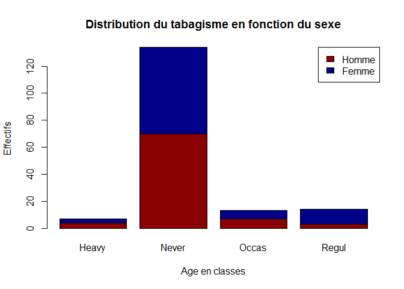

Remarquer qu’il y a plus de femmes que des hommes fument régulièrement. (selon l’enquête réalisée)

**Indicateurs pour le croisement d’une variable qualitative et d’une variable quantitative**

Disons qu’on souhaite calculer la moyenne de fréquence cardiaque chez les hommes ayant répondu au questionnaire de l’enquête. On a besoin de filtrer le dataframe de la façon suivante:

```r
pulse_hommes = subset(donnees, donnees$Sex=="Male")
## On utilise la fontion subset pour créer un sous ensemble de nos données
## Remarquer qu'on utilise == pour comparer
```

**15.** Vérifier que le sous ensemble créé `pulse_homme` ne contient que des hommes.

**16.** Ensuite calculer les indicateurs statistiques de la fréquence cardiaque chez les hommes (vous pouvez utiliser la fonction `summary()`).

**17.** Faire la même chose mais pour les femmes.

**Représentation graphique pour le croisement d’une variable qualitative et d’une variable quantitative**

On peut réaliser une boîte à moustache des valeurs de la variable quantitative en fonction des modalités de la variables qualitative, pour cela on peut utliser la fonction `boxplot()`. Plus précisémeent, on utilise le paramètre `formula` qui permet de spécifier que nous voulons une boîte à moustache de la variable quantitative en fonction (caractère `~` ) de la variable quantitative.

**18.** Afficher sur la même figure la fréquence cardiaque en fontion du sexe. Interpréter la figure.

La figure souhaitée est la suivante:

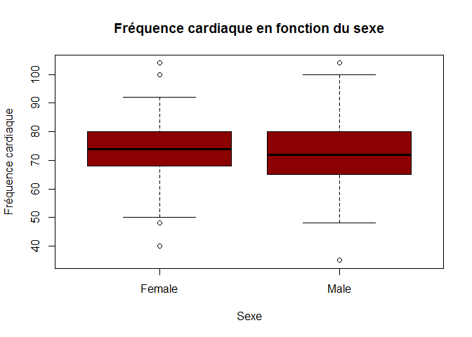

**19.** Afficher sur la même figure la taille (variable `Height`) en fontion du sexe. Interpréter la figure.

**Représentation graphique pour le croisement de deux variables quantitatives**

Un nuage de points entre les deux variables quantitatives est réalisé par la fonction `plot()`. Le premier paramètre correspond à la variable en abscisse et le deuxième à la variable en ordonnées.

**20.** Afficher la fréquence cardiaque en fonction de l’age. Modifier les paramètres de la figure (titre, noms des axes, couleurs des points, tailles, formes, etc..)

◼ Fin